# **Cat Anatomy Report**

Andrew Wang** North Carolina School of Science and Mathematics

August 30, 2020

**Abstract**

This document provides a report on data related to cat anatomy, specifically heart weight in grams, body weight in kilograms, and gender

### **Model Setup**

In this section, we established the basic parameters of the model, including cleaning up old data, setting up the working directory, and loading a separate file of useful functions.

```r
rm(list=ls())
setwd("C:/Users/hyper/OneDrive/Desktop/Desktop Folders/Programming/R")
source("./myfunctions.R")
```

### **Loading Libraries**

For this study, we are using the MASS package (Modern Applied Statistics with S, from Venables and Ripley). In this package, there are a number of datasets ready for analysis, including the cats dataset.

```r
# load data from the MASS library
library(MASS)
```

```r
## Warning: package 'MASS' was built under R version 3.5.2
```

### **Data Demographics**

In this section, we look at the basic structure of the data: the head of the data file, which shows the names of the columns and a representative sample of the first several rows of data; the dimension of the data (number of rows and columns); and a descriptive statistical summary of the dataset.

```r
head(cats)
```

```
##   Sex Bwt Hwt
## 1   F 2.0 7.0
## 2   F 2.0 7.4
## 3   F 2.0 9.5
## 4   F 2.1 7.2
## 5   F 2.1 7.3
## 6   F 2.1 7.6
```

```r
dim(cats)
```

```
## [1] 144   3
```

```r
summary(cats)
```

```
##  Sex         Bwt             Hwt
##  F:47   Min.   :2.000   Min.   : 6.30
##  M:97   1st Qu.:2.300   1st Qu.: 8.95
##         Median :2.700   Median :10.10
##         Mean   :2.724   Mean   :10.63
##         3rd Qu.:3.025   3rd Qu.:12.12
##         Max.   :3.900   Max.   :20.50
```

#### **Nicer looking summary table**

We can use tools such as knitr/kable to display data tables in a nicer looking format. In this section, we are displaying the summary descriptive statistics table using these tools.

```r
knitr::kable(
summary(cats),
caption = "Table 1: Summary table of cat anatomy data"
)
```

Table 1: Summary table of cat anatomy data

|  | Sex | Bwt | Hwt |
| --- | --- | --- | --- |
|  | F:47 | Min. :2.000 | Min. : 6.30 |
|  | M:97 | 1st Qu.:2.300 | 1st Qu.: 8.95 |
|  | NA | Median :2.700 | Median :10.10 |
|  | NA | Mean :2.724 | Mean :10.63 |
|  | NA | 3rd Qu.:3.025 | 3rd Qu.:12.12 |
|  | NA | Max. :3.900 | Max. :20.50 |

### **Data munging: rename columns, data in columns**

“Data munging” is a computer science term that basically means cleaning up the data, usually in fairly destructive ways (not always a bad thing). In this section, we are changing the existing column names (sex, bwt,hwt) to something more readable: Gender, BodyWeight and HeartWeight. Having longer column names has its problems (more typing), but does make your dataset more human-friendly! Likewise, we are changing gender from F/M to Female/Male.

```r
colnames(cats) <- c("Gender", "BodyWeight", "HeartWeight")
names(cats)
```

```
## [1] "Gender"      "BodyWeight"  "HeartWeight"
```

```r
cats$Gender <- factor(cats$Gender, levels = c("F", "M"), labels = c("Female", "Male"))
head(cats)
```

```
##   Gender BodyWeight HeartWeight
## 1 Female        2.0         7.0
## 2 Female        2.0         7.4
## 3 Female        2.0         9.5
## 4 Female        2.1         7.2
## 5 Female        2.1         7.3
## 6 Female        2.1         7.6
```

### **Graphical Representations**

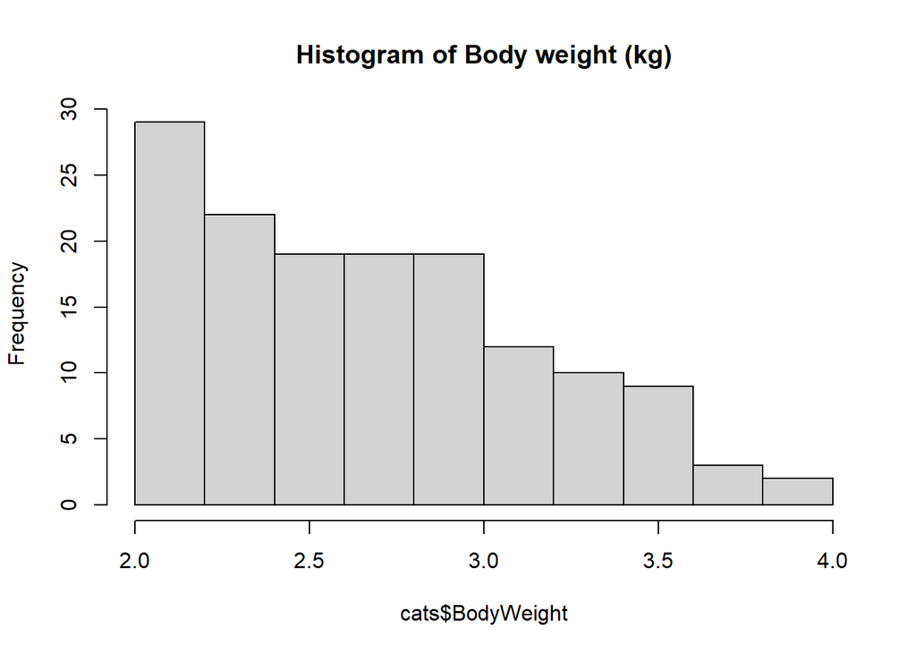

```r
hist(cats$BodyWeight, main="Histogram of Body weight (kg)")
```

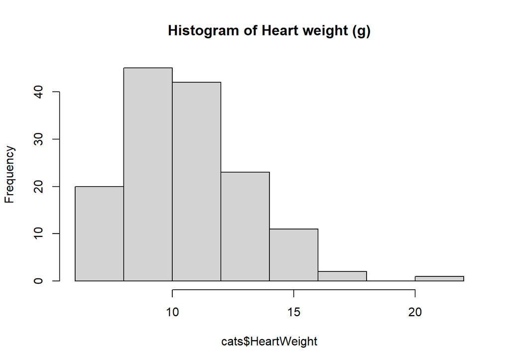

```r
hist(cats$HeartWeight, main="Histogram of Heart weight (g)")
```

Pairwise plot of relevant data

We now use one of the builtin functions from myfunctions.R to create a pairwise plot. This shows histograms of all of the data, a scatter plot of each pair of data, and a correlation coefficient between each pair.

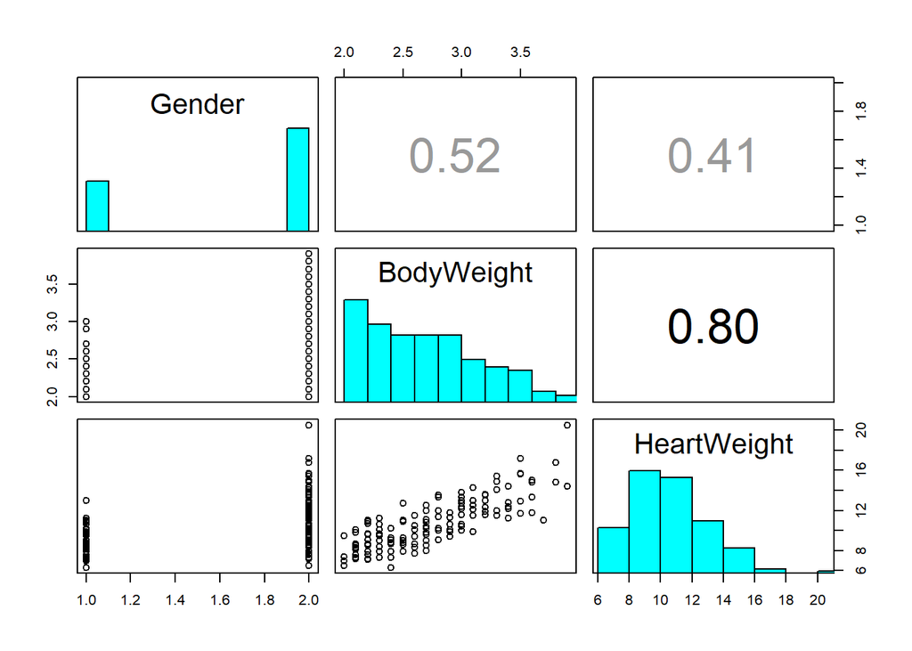

```r
pairs(cats,upper.panel=panel.cor,diag.panel=panel.hist)
```

#### **Plot of heart weight as a function of body weight (with linear regression line)**

Finally, we run a scatter plot of heart weight as a function of body weight. Notice that the data is fairly linear, supported by plotting a linear regression line on top of the raw data.

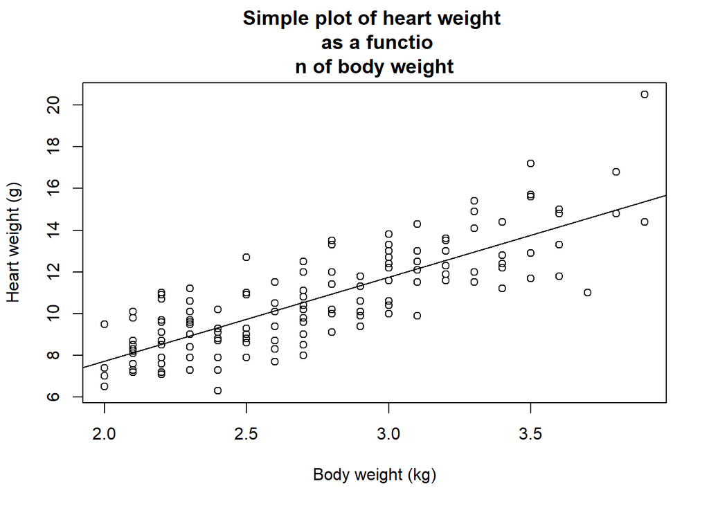

```r
plot(cats$HeartWeight~cats$BodyWeight, main="Simple plot of heart weight \n as a functio
n of body weight", xlab="Body weight (kg)", ylab="Heart weight (g)")
fit<- lm(cats$HeartWeight~cats$BodyWeight)
abline(fit)
```